# Project 7- Unsupervised Learning

```python
pip install -U yellowbrick
```

[output not shown]

```python
%reset
```

```
Once deleted, variables cannot be recovered. Proceed (y/[n])? y
```

# Importing Required Packages

```python
# Libraries to help with reading and manipulating data
import numpy as np
import pandas as pd

# Libraries to help with data visualization
import matplotlib.pyplot as plt
import seaborn as sns

# to scale the data using z-score
from sklearn.preprocessing import StandardScaler

# to compute distances
from scipy.spatial.distance import cdist

# to compute distances
from scipy.spatial.distance import pdist

# to perform k-means clustering and compute silhouette scores
from sklearn.cluster import KMeans
from sklearn.metrics import silhouette_score

# to perform hierarchical clustering, compute cophenetic correlation, and create dendrograms
from sklearn.cluster import AgglomerativeClustering
from scipy.cluster.hierarchy import dendrogram, linkage, cophenet

# to visualize the elbow curve and silhouette scores
from yellowbrick.cluster import KElbowVisualizer, SilhouetteVisualizer
```

# Importing and understanding the dataset

```python
df = pd.read_excel('/Users/KrithikaSrinivasan/Documents/Data Science and Business Analytics/Data-Science-and-Business-Analytics/Module 7- Unsupervised Learning/Credit Card Customer Data.xlsx')
np.random.seed(1)
df.head()
```

|  | Sl_No | Customer Key | Avg_Credit_Limit | Total_Credit_Cards | Total_visits_bank | Total_visits_online | Total_calls_made |
| --- | --- | --- | --- | --- | --- | --- | --- |
| 0 | 1 | 87073 | 100000 | 2 | 1 | 1 | 0 |
| 1 | 2 | 38414 | 50000 | 3 | 0 | 10 | 9 |
| 2 | 3 | 17341 | 50000 | 7 | 1 | 3 | 4 |
| 3 | 4 | 40496 | 30000 | 5 | 1 | 1 | 4 |
| 4 | 5 | 47437 | 100000 | 6 | 0 | 12 | 3 |

```python
# creating a copy of the dataset
df_copy = df.copy()
df_copy.head()
```

|  | Sl_No | Customer Key | Avg_Credit_Limit | Total_Credit_Cards | Total_visits_bank | Total_visits_online | Total_calls_made |
| --- | --- | --- | --- | --- | --- | --- | --- |
| 0 | 1 | 87073 | 100000 | 2 | 1 | 1 | 0 |
| 1 | 2 | 38414 | 50000 | 3 | 0 | 10 | 9 |
| 2 | 3 | 17341 | 50000 | 7 | 1 | 3 | 4 |
| 3 | 4 | 40496 | 30000 | 5 | 1 | 1 | 4 |
| 4 | 5 | 47437 | 100000 | 6 | 0 | 12 | 3 |

```python
# shape of the dataset
print(f'The dataset has {df.shape[0]} rows and {df.shape[1]} columns')
```

```
The dataset has 660 rows and 7 columns
```

```python
# check for null values
df.isnull().sum()
```

```
Sl_No                  0
Customer Key           0
Avg_Credit_Limit       0
Total_Credit_Cards     0
Total_visits_bank      0
Total_visits_online    0
Total_calls_made       0
dtype: int64
```

No null values in the dataset

```python
# checking for duplicate rows
df[df.duplicated()].count()
```

```
Sl_No                  0
Customer Key           0
Avg_Credit_Limit       0
Total_Credit_Cards     0
Total_visits_bank      0
Total_visits_online    0
Total_calls_made       0
dtype: int64
```

No duplicate rows in the dataset

```python
df.dtypes
```

```
Sl_No                  int64
Customer Key           int64
Avg_Credit_Limit       int64
Total_Credit_Cards     int64
Total_visits_bank      int64
Total_visits_online    int64
Total_calls_made       int64
dtype: object
```

```python
df.describe().T
```

|  | count | mean | std | min | 25% | 50% | 75% | max |
| --- | --- | --- | --- | --- | --- | --- | --- | --- |
| Sl_No | 660.0 | 330.500000 | 190.669872 | 1.0 | 165.75 | 330.5 | 495.25 | 660.0 |
| Customer Key | 660.0 | 55141.443939 | 25627.772200 | 11265.0 | 33825.25 | 53874.5 | 77202.50 | 99843.0 |
| Avg_Credit_Limit | 660.0 | 34574.242424 | 37625.487804 | 3000.0 | 10000.00 | 18000.0 | 48000.00 | 200000.0 |
| Total_Credit_Cards | 660.0 | 4.706061 | 2.167835 | 1.0 | 3.00 | 5.0 | 6.00 | 10.0 |
| Total_visits_bank | 660.0 | 2.403030 | 1.631813 | 0.0 | 1.00 | 2.0 | 4.00 | 5.0 |
| Total_visits_online | 660.0 | 2.606061 | 2.935724 | 0.0 | 1.00 | 2.0 | 4.00 | 15.0 |
| Total_calls_made | 660.0 | 3.583333 | 2.865317 | 0.0 | 1.00 | 3.0 | 5.00 | 10.0 |

# Observations

1. SI_No is just a serial number for each record. This column can be dropped.
2. Customer Key is a customer identification number for each custoemr.
3. Avg_Credit_Limit has a mean of around 34K.
4. Total_Credit_Cards has a mean of 4.7, which means that on average a customer has ~5 credit cards.
5. Total_visits_bank has a mean of 2.4 which is close to the median.
6. Total_visits_online has a mean of 2.6 which is close to the median.
7. Total_calls_made has a mean of 3.5 which is close to the median.

# Exploratory Data Analysis

## Univariate Analysis

### Customer Key

```python
df['Customer Key'].nunique()
```

```
655
```

There are 655 unique customer keys, which means there are 5 repeated customers in the dataset

```python
# customer key values that have duplicates
df[df['Customer Key'].duplicated() == True]
```

|  | Sl_No | Customer Key | Avg_Credit_Limit | Total_Credit_Cards | Total_visits_bank | Total_visits_online | Total_calls_made |
| --- | --- | --- | --- | --- | --- | --- | --- |
| 332 | 333 | 47437 | 17000 | 7 | 3 | 1 | 0 |
| 398 | 399 | 96929 | 67000 | 6 | 2 | 2 | 2 |
| 432 | 433 | 37252 | 59000 | 6 | 2 | 1 | 2 |
| 541 | 542 | 50706 | 60000 | 7 | 5 | 2 | 2 |
| 632 | 633 | 97935 | 187000 | 7 | 1 | 7 | 0 |

```python
df[df['Customer Key'] == 47437]
```

|  | Sl_No | Customer Key | Avg_Credit_Limit | Total_Credit_Cards | Total_visits_bank | Total_visits_online | Total_calls_made |
| --- | --- | --- | --- | --- | --- | --- | --- |
| 4 | 5 | 47437 | 100000 | 6 | 0 | 12 | 3 |
| 332 | 333 | 47437 | 17000 | 7 | 3 | 1 | 0 |

There are 5 duplicates in the Customer Key column. These need to be treated.

### Avg_Credit_Limit

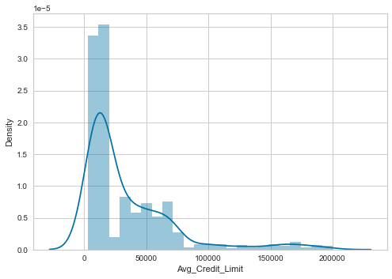

```python
sns.distplot(df['Avg_Credit_Limit']);
```

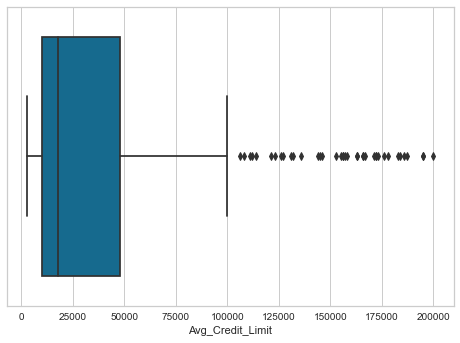

```python
sns.boxplot(df['Avg_Credit_Limit']);
```

This column in highly right skewed, which means most of the customers have a lower avg_credit_limit with a few  
customers having high avg_credit_limit. This column needs to be standardized in the data prep step.  
Looks like there are outliers in this column.

### Total_Credit_Cards

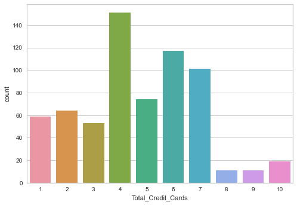

```python
sns.countplot(df['Total_Credit_Cards']);
```

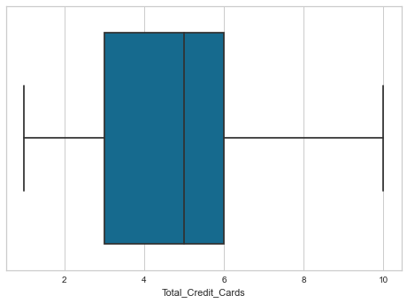

```python
sns.boxplot(df['Total_Credit_Cards']);
```

Most customers have 4 credit cards, followed by those who have 6 credit cards.  
No outliers in this column.

### Total_visits_bank

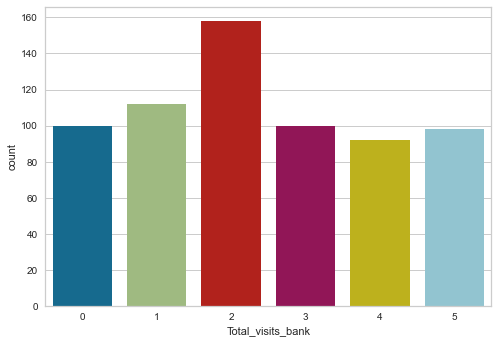

```python
sns.countplot(df['Total_visits_bank']);
```

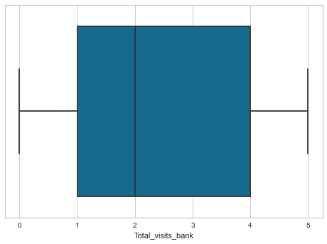

```python
sns.boxplot(df['Total_visits_bank']);
```

Most customers visit the bank twice yearly, followed by those customers who visit once.  
No outliers in this column.

### Total_visits_online

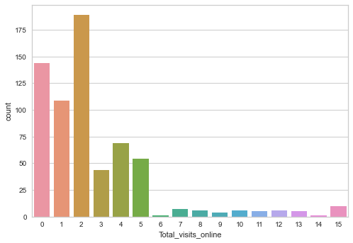

```python
sns.countplot(df['Total_visits_online']);
```

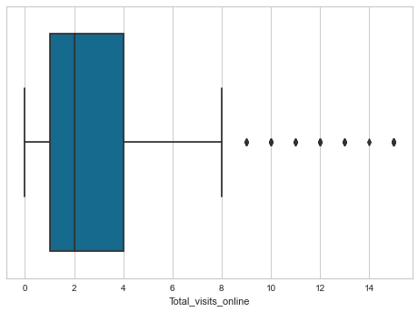

```python
sns.boxplot(df['Total_visits_online']);
```

Most customers visit the bank website only twice a year, followed by those who never visit the website.  
Looks like there are outliers in this column. This needs to be processed before clustering.

### Total_calls_made

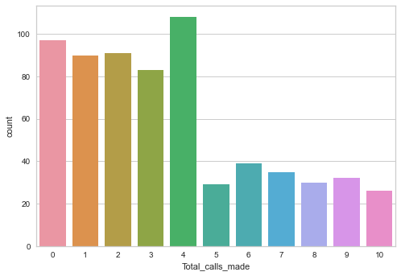

```python
sns.countplot(df['Total_calls_made']);
```

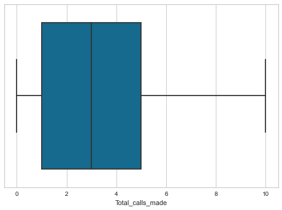

```python
sns.boxplot(df['Total_calls_made']);
```

Most customers have called the bank 4 times in a year, followed by those who never call the bank.  
No outliers in this column.

## Bivariate Analysis

```python
df.head()
```

|  | Sl_No | Customer Key | Avg_Credit_Limit | Total_Credit_Cards | Total_visits_bank | Total_visits_online | Total_calls_made |
| --- | --- | --- | --- | --- | --- | --- | --- |
| 0 | 1 | 87073 | 100000 | 2 | 1 | 1 | 0 |
| 1 | 2 | 38414 | 50000 | 3 | 0 | 10 | 9 |
| 2 | 3 | 17341 | 50000 | 7 | 1 | 3 | 4 |
| 3 | 4 | 40496 | 30000 | 5 | 1 | 1 | 4 |
| 4 | 5 | 47437 | 100000 | 6 | 0 | 12 | 3 |

### Avg_Credit_Limit

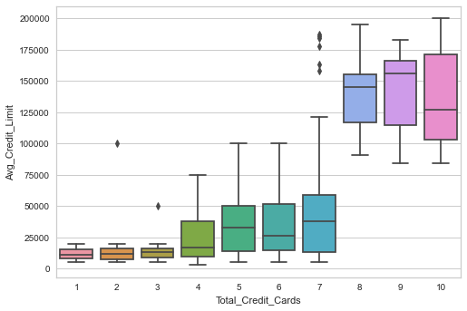

```python
sns.boxplot(y="Avg_Credit_Limit", x="Total_Credit_Cards", data=df, orient="vertical");
```

We can see that higher the Avg_Credit_Limit, higher is the number of credit cards possessed by the customer.

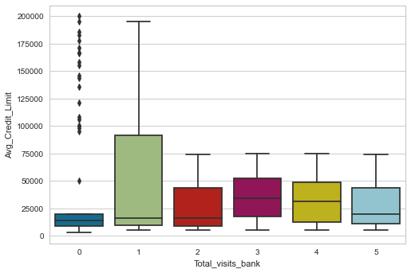

```python
sns.boxplot(y="Avg_Credit_Limit", x="Total_visits_bank", data=df, orient="vertical");
```

No specific pattern/correlation in terms of these two variables.

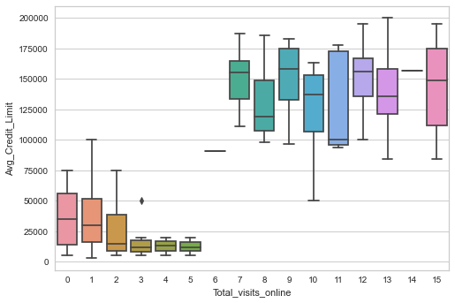

```python
sns.boxplot(y="Avg_Credit_Limit", x="Total_visits_online", data=df, orient="vertical");
```

We can see that higher the Avg_Credit_Limit, higher is the number of visits made to the banks website.

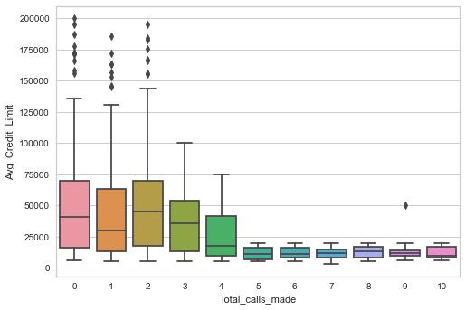

```python
sns.boxplot(y="Avg_Credit_Limit", x="Total_calls_made", data=df, orient="vertical");
```

### Total_Credit_Cards

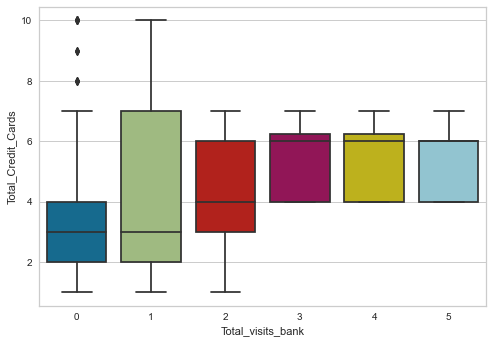

```python
sns.boxplot(y="Total_Credit_Cards", x="Total_visits_bank", data=df, orient="vertical");
```

No specific pattern/correlation in terms of these two variables.

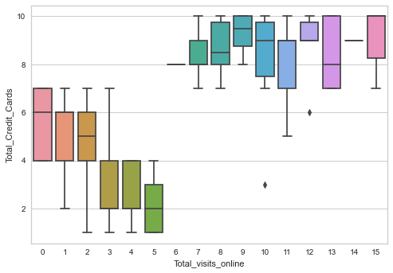

```python
sns.boxplot(y="Total_Credit_Cards", x="Total_visits_online", data=df, orient="vertical");
```

We can see that greater the number of credit cards, higher is the number of visits made to the banks website.

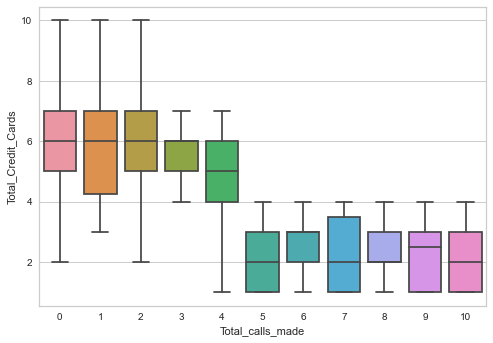

```python
sns.boxplot(y="Total_Credit_Cards", x="Total_calls_made", data=df, orient="vertical");
```

We can see that greater the number of credit cards, less calls are made to the bank.

### Total_visits_bank

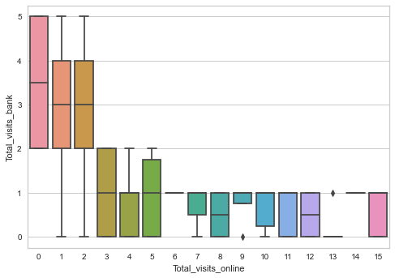

```python
sns.boxplot(y="Total_visits_bank", x="Total_visits_online", data=df, orient="vertical");
```

We can see that greater the number of online visits, lesser is the number of bank visits.

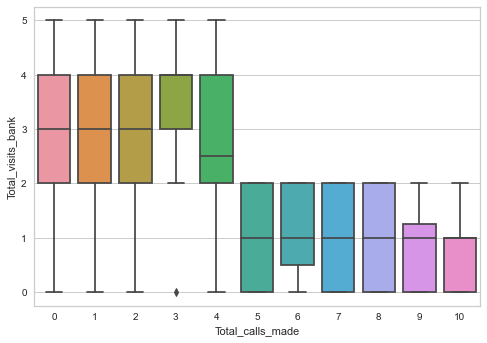

```python
sns.boxplot(y="Total_visits_bank", x="Total_calls_made", data=df, orient="vertical");
```

We can see that smaller the number of total calls made, greater is the total number of bank visits.

### Total_visits_online

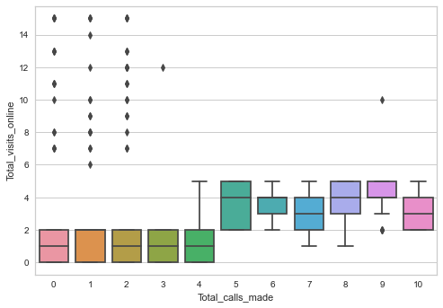

```python
sns.boxplot(y="Total_visits_online", x="Total_calls_made", data=df, orient="vertical");
```

No specific pattern/correlation in terms of these two variables.

```python
df.corr()
```

|  | Sl_No | Customer Key | Avg_Credit_Limit | Total_Credit_Cards | Total_visits_bank | Total_visits_online | Total_calls_made |
| --- | --- | --- | --- | --- | --- | --- | --- |
| Sl_No | 1.000000 | 0.052886 | 0.677962 | 0.739329 | 0.406438 | 0.033916 | -0.684125 |
| Customer Key | 0.052886 | 1.000000 | 0.068604 | -0.010281 | -0.000560 | 0.022506 | 0.005968 |
| Avg_Credit_Limit | 0.677962 | 0.068604 | 1.000000 | 0.608860 | -0.100312 | 0.551385 | -0.414352 |
| Total_Credit_Cards | 0.739329 | -0.010281 | 0.608860 | 1.000000 | 0.315796 | 0.167758 | -0.651251 |
| Total_visits_bank | 0.406438 | -0.000560 | -0.100312 | 0.315796 | 1.000000 | -0.551861 | -0.506016 |
| Total_visits_online | 0.033916 | 0.022506 | 0.551385 | 0.167758 | -0.551861 | 1.000000 | 0.127299 |
| Total_calls_made | -0.684125 | 0.005968 | -0.414352 | -0.651251 | -0.506016 | 0.127299 | 1.000000 |

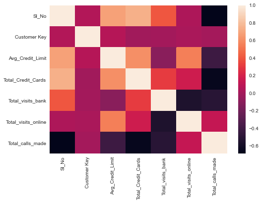

```python
sns.heatmap(df.corr());
```

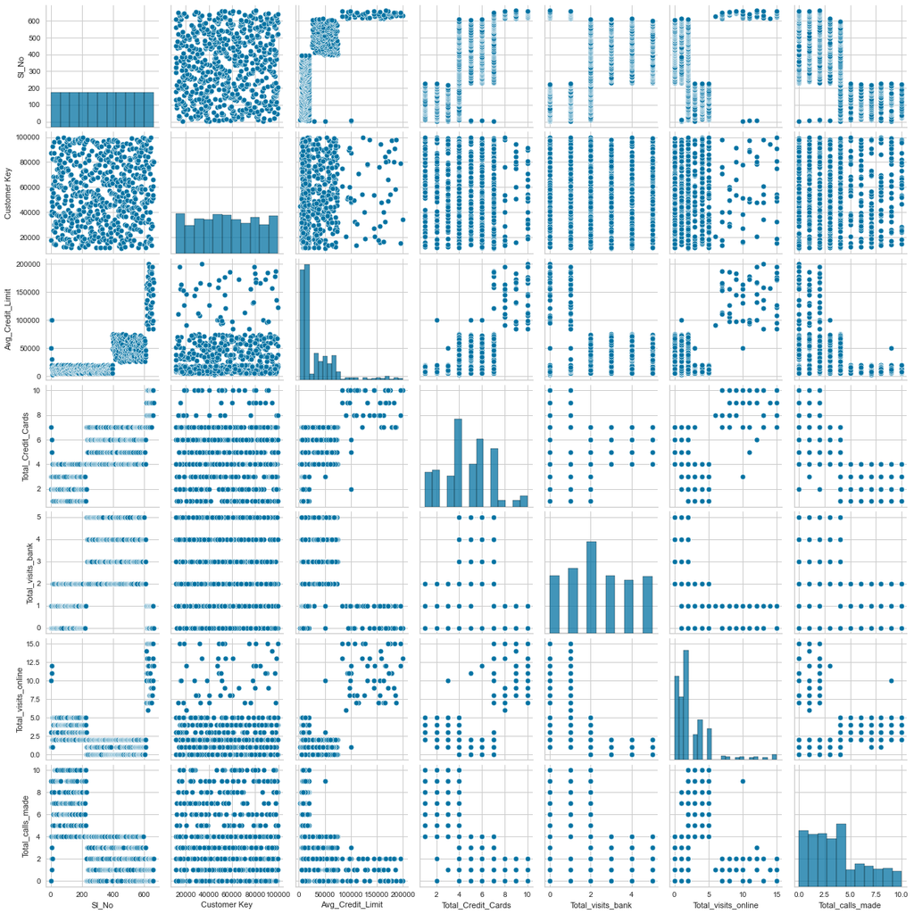

```python
sns.pairplot(df);
```

# Data Preprocessing

```python
# dropping columns Sl_No and Customer Key since they are identifiers for records and customers respectively
df.drop(['Sl_No', 'Customer Key'], inplace=True, axis=1)
```

```python
# selecting numerical columns
num_col = df.select_dtypes(include=np.number).columns.tolist()
```

```python
num_col
```

```
['Avg_Credit_Limit',
 'Total_Credit_Cards',
 'Total_visits_bank',
 'Total_visits_online',
 'Total_calls_made']
```

```python
# scaling the data set before clustering
scaler = StandardScaler()
subset = df[num_col].copy()
subset_scaled = scaler.fit_transform(subset)
```

```python
# creating a dataframe from the scaled data
subset_scaled_df = pd.DataFrame(subset_scaled, columns=subset.columns)
```

# K-means Clustering

## Elbow Curve

```
Number of Clusters: 1 	Average Distortion: 2.0069222262503614
Number of Clusters: 2 	Average Distortion: 1.4571553548514269
Number of Clusters: 3 	Average Distortion: 1.1466276549150365
Number of Clusters: 4 	Average Distortion: 1.0463825294774465
Number of Clusters: 5 	Average Distortion: 0.9908683849620168
Number of Clusters: 6 	Average Distortion: 0.9431306087808111
Number of Clusters: 7 	Average Distortion: 0.9228219141364191
Number of Clusters: 8 	Average Distortion: 0.8912155076516123
```

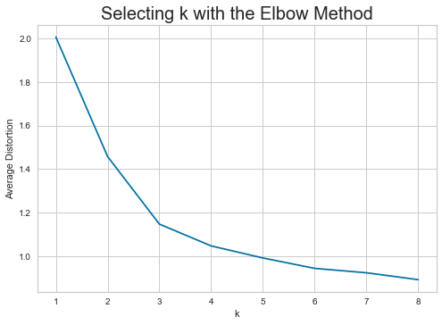

```python
clusters = range(1, 9)
meanDistortions = []

for k in clusters:
    model = KMeans(n_clusters=k)
    model.fit(subset_scaled_df)
    prediction = model.predict(subset_scaled_df)
    distortion = (
        sum(
            np.min(cdist(subset_scaled_df, model.cluster_centers_, "euclidean"), axis=1)
        )
        / subset_scaled_df.shape[0]
    )

    meanDistortions.append(distortion)

    print("Number of Clusters:", k, "\tAverage Distortion:", distortion)

plt.plot(clusters, meanDistortions, "bx-")
plt.xlabel("k")
plt.ylabel("Average Distortion")
plt.title("Selecting k with the Elbow Method", fontsize=20)
```

## Silhouette Score

```
For n_clusters = 2, silhouette score is 0.41842496663230405
For n_clusters = 3, silhouette score is 0.5157182558882754
For n_clusters = 4, silhouette score is 0.355667061937737
For n_clusters = 5, silhouette score is 0.2717470361094591
For n_clusters = 6, silhouette score is 0.2553480159474374
For n_clusters = 7, silhouette score is 0.23394349730075736
For n_clusters = 8, silhouette score is 0.22680516398659234
For n_clusters = 9, silhouette score is 0.21075690862137694
```

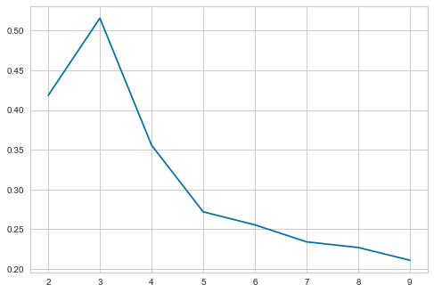

```python
sil_score = []
cluster_list = list(range(2, 10))
for n_clusters in cluster_list:
    clusterer = KMeans(n_clusters=n_clusters)
    preds = clusterer.fit_predict((subset_scaled_df))
    # centers = clusterer.cluster_centers_
    score = silhouette_score(subset_scaled_df, preds)
    sil_score.append(score)
    print("For n_clusters = {}, silhouette score is {}".format(n_clusters, score))

plt.plot(cluster_list, sil_score)
```

Appropriate number of clusters = 3 as there is a slight elbow at 3 and the silhouette score for 3 clusters is the highest

```python
kmeans = KMeans(n_clusters=3, random_state=0)
kmeans.fit(subset_scaled_df)
```

```
KMeans(n_clusters=3, random_state=0)
```

```python
# adding kmeans cluster labels to the original dataframe
df['K_means_segments'] = kmeans.labels_
```

## Cluster Profiling

```python
cluster_profile = df.groupby('K_means_segments').mean()
```

```python
cluster_profile['count_in_each_segment'] = (
    df.groupby('K_means_segments')['Total_Credit_Cards'].count().values
)
```

```python
# let's display cluster profiles
cluster_profile.style.highlight_max(color="lightgreen", axis=0)
```

| K_means_segments | Avg_Credit_Limit | Total_Credit_Cards | Total_visits_bank | Total_visits_online | Total_calls_made | count_in_each_segment |
| --- | --- | --- | --- | --- | --- | --- |
| 0 | 33782.383420 | 5.515544 | 3.489637 | 0.981865 | 2.000000 | 386 |
| 1 | 12174.107143 | 2.410714 | 0.933036 | 3.553571 | 6.870536 | 224 |
| 2 | 141040.000000 | 8.740000 | 0.600000 | 10.900000 | 1.080000 | 50 |

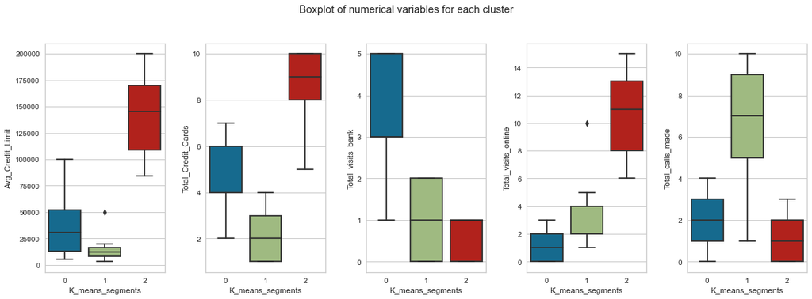

```python
fig, axes = plt.subplots(1, 5, figsize=(16, 6))
fig.suptitle("Boxplot of numerical variables for each cluster")
counter = 0
for ii in range(5):
    sns.boxplot(ax=axes[ii], y=df[num_col[counter]], x=df['K_means_segments'])
    counter = counter + 1

fig.tight_layout(pad=2.0)
```

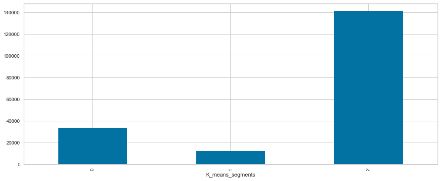

```python
df['Avg_Credit_Limit'].groupby(df['K_means_segments']).mean().plot.bar(figsize=(15, 6))
```

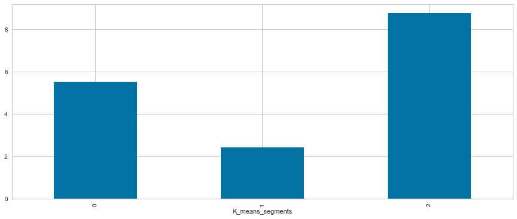

```python
df['Total_Credit_Cards'].groupby(df['K_means_segments']).mean().plot.bar(figsize=(15, 6))
```

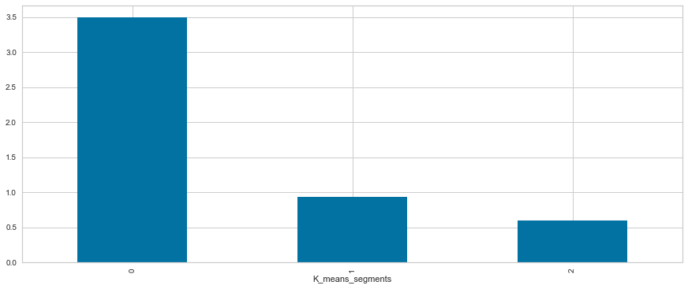

```python
df['Total_visits_bank'].groupby(df['K_means_segments']).mean().plot.bar(figsize=(15, 6))
```

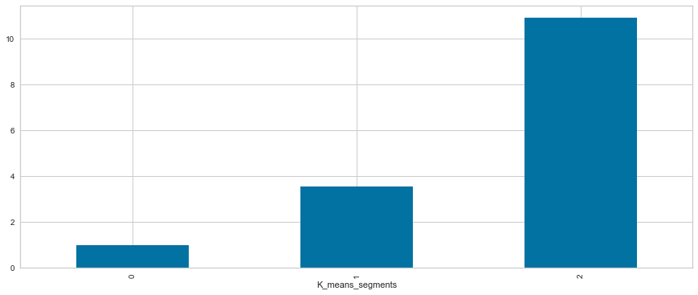

```python
df['Total_visits_online'].groupby(df['K_means_segments']).mean().plot.bar(figsize=(15, 6))
```

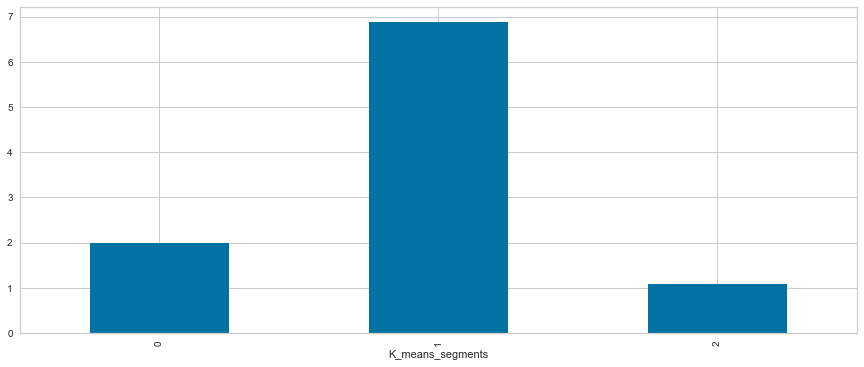

```python
df['Total_calls_made'].groupby(df['K_means_segments']).mean().plot.bar(figsize=(15, 6))
```

# Hierarchical Clustering

```python
# list of distance metrics
distance_metrics = ["euclidean", "chebyshev", "mahalanobis", "cityblock"]

# list of linkage methods
linkage_methods = ["single", "complete", "average", "weighted"]

high_cophenet_corr = 0
high_dm_lm = [0, 0]

for dm in distance_metrics:
    for lm in linkage_methods:
        Z = linkage(subset_scaled_df, metric=dm, method=lm)
        c, coph_dists = cophenet(Z, pdist(subset_scaled_df))
        print(
            "Cophenetic correlation for {} distance and {} linkage is {}.".format(
                dm.capitalize(), lm, c
            )
        )
        if high_cophenet_corr < c:
            high_cophenet_corr = c
            high_dm_lm[0] = dm
            high_dm_lm[1] = lm
```

```
Cophenetic correlation for Euclidean distance and single linkage is 0.7391220243806552.
Cophenetic correlation for Euclidean distance and complete linkage is 0.8599730607972423.
Cophenetic correlation for Euclidean distance and average linkage is 0.8977080867389372.
Cophenetic correlation for Euclidean distance and weighted linkage is 0.8861746814895477.
Cophenetic correlation for Chebyshev distance and single linkage is 0.7382354769296767.
Cophenetic correlation for Chebyshev distance and complete linkage is 0.8533474836336782.
Cophenetic correlation for Chebyshev distance and average linkage is 0.8974159511838106.
Cophenetic correlation for Chebyshev distance and weighted linkage is 0.8913624010768603.
Cophenetic correlation for Mahalanobis distance and single linkage is 0.7058064784553605.
Cophenetic correlation for Mahalanobis distance and complete linkage is 0.6663534463875362.
Cophenetic correlation for Mahalanobis distance and average linkage is 0.8326994115042136.
Cophenetic correlation for Mahalanobis distance and weighted linkage is 0.780599061514252.
Cophenetic correlation for Cityblock distance and single linkage is 0.7252379350252723.
Cophenetic correlation for Cityblock distance and complete linkage is 0.8731477899179829.
Cophenetic correlation for Cityblock distance and average linkage is 0.896329431104133.
Cophenetic correlation for Cityblock distance and weighted linkage is 0.8825520731498188.
```

```python
# printing the combination of distance metric and linkage method with the highest cophenetic correlation
print(
    "Highest cophenetic correlation is {}, which is obtained with {} distance and {} linkage.".format(
        high_cophenet_corr, high_dm_lm[0].capitalize(), high_dm_lm[1]
    )
)
```

```
Highest cophenetic correlation is 0.8977080867389372, which is obtained with Euclidean distance and average linkage.
```

## Exploring different linkage methods with Euclidean distance

```python
# list of linkage methods
linkage_methods = ["single", "complete", "average", "centroid", "ward", "weighted"]

high_cophenet_corr = 0
high_dm_lm = [0, 0]

for lm in linkage_methods:
    Z = linkage(subset_scaled_df, metric="euclidean", method=lm)
    c, coph_dists = cophenet(Z, pdist(subset_scaled_df))
    print("Cophenetic correlation for {} linkage is {}.".format(lm, c))
    if high_cophenet_corr < c:
        high_cophenet_corr = c
        high_dm_lm[0] = "euclidean"
        high_dm_lm[1] = lm
```

```
Cophenetic correlation for single linkage is 0.7391220243806552.
Cophenetic correlation for complete linkage is 0.8599730607972423.
Cophenetic correlation for average linkage is 0.8977080867389372.
Cophenetic correlation for centroid linkage is 0.8939385846326323.
Cophenetic correlation for ward linkage is 0.7415156284827493.
Cophenetic correlation for weighted linkage is 0.8861746814895477.
```

We see that the correlation is maximum with Euclidian distance and average linkage.